# **IMPACT OF THE SELECTED FEATURES IN THE MODEL**

```python
import sys
sys.path.append("..") # append the directory above where the databese is.
from utils import config
import pandas as pd
import numpy as np
import sqlite3
import xgboost as xgb
import shap
import matplotlib.pyplot as plt
import sklearn

from sklearn.ensemble import GradientBoostingRegressor
from sklearn.model_selection import train_test_split, GridSearchCV, KFold, cross_val_score
from sklearn.metrics import r2_score, mean_absolute_error, mean_squared_error

shap.initjs()
### disable scientific notation in pandas
pd.set_option('display.float_format', '{:.2f}'.format) ### display up to 2 decimal pts
```

```python
with sqlite3.connect(config.DATABASE_PATH) as connection:
    df = pd.read_sql("SELECT * FROM CountryIndicators", connection)
```

```python
def clean_and_pivote(df):
    countries_gdp = df[df["IndicatorCode"] == config.GDP_GROWTH]["CountryCode"].to_list() #countries with gdp
    countries = df["CountryCode"].unique()
    countries_no_gdp = list(set(sorted(countries)) - set(sorted(countries_gdp))) # set difference =  countries with no gdp

    return df.pivot(index=["CountryCode","Year"], columns="IndicatorCode", values="Value").drop(countries_no_gdp)
```

```python
df_cleaned = clean_and_pivote(df)
df_cleaned = df_cleaned[config.MODEL_FEATURES]
df_cleaned.drop(index=range(1960, 1980), level="Year", inplace=True)
```

[output not shown]

```python
df_features = df_cleaned.copy()
df_target = df_cleaned.pop(config.GDP_GROWTH)
df_features.drop(index=2010, level="Year", inplace=True)
df_target.drop(index=1980, level="Year", inplace=True)
```

```python
X = df_features
y = df_target.to_frame()
# genereate imputed dataframes by mean
X_imp = X.fillna(X.mean())
X_imp = np.array(X_imp)
y_imp = y.fillna(y.mean())
y_imp = np.array(y_imp)
```

```python
X_train, X_test, y_train, y_test = train_test_split(X_imp, y_imp, test_size=0.2, random_state=1)
```

```python
model = xgb.XGBRegressor(max_depth=9, learning_rate=0.01, subsample=0.8, n_estimators=1000, base_score=y_train.mean())
model.fit(X_train, y_train)
explainer = shap.TreeExplainer(model)
shap_values = explainer.shap_values(X_test)
vals = np.abs(shap_values).mean(0)
feature_importance = pd.DataFrame(list(zip(config.FEATURE_LABELS,vals)), columns=['col_name', 'feature_importance_vals'])
```

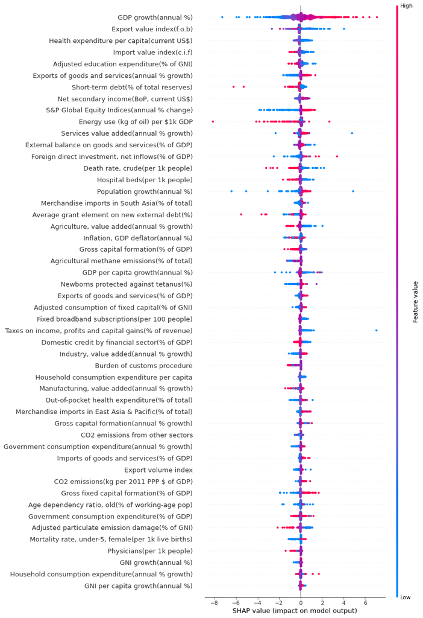

```python
shap.summary_plot(shap_values, X_test, show=False, max_display=50,
                  feature_names=list(config.FEATURE_LABELS))
```

In this plot we can see the impact of each 50 features, in descending order, in each observation.

The most important feature, by far, is the value of the *GDP Growth (annual \%) of the actual year*, which makes sense given that we are trying to predict the *GDP Growth of the next year*. Both variables are directly correlated, high values of *GDP Growth of the actual year* imply a positive impact in the predictions of the *GDP Growth of the next year*, this positive relationship appears, to a lesser extent, in other features like *Exports of goods and services (annual % growth)*, *S&P Global Equity Indices (annual % change)*, etc.

On the other hand, there are negative relations, for example, for lower values of *Import value index (c.i.f)* we obtain higher values of *GDP Growth of the next year*.

A remarkable thing is the features like *Energy use (kg of oil) per $1k GDP* and *Government consumption expenditure(\% of GDP)*. These features seem only have and important impact when they have high values. We can interpret that a higher *Energy use* can affect in both 'directions', positively or negatively, in the *GDP Growth of the next year* and a lower *Energy use* has an impact in the *GDP Growth of the next year* close to 0.

## **Correlation matrix**

Furthermore, we can compute the correlation matrix to obtain more information about the relation between the features.

```python
corr = df_cleaned.corr()
corr.columns = list(config.FEATURE_LABELS)
corr.index = list(config.FEATURE_LABELS)
corr.style.background_gradient(cmap='coolwarm', axis=None).set_precision(3)
```

|  | GDP growth(annual %) | Import value index(c.i.f) | Health expenditure per capita(current US$) | Export value index(f.o.b) | Exports of goods and services(annual % growth) | S&P Global Equity Indices(annual % change) | Services value added(annual % growth) | Net secondary income(BoP, current US$) | Adjusted education expenditure(% of GNI) | Agriculture, value added(annual % growth) | Short-term debt(% of total reserves) | Inflation, GDP deflator(annual %) | Gross capital formation(% of GDP) | GDP per capita growth(annual %) | Energy use (kg of oil) per $1k GDP | External balance on goods and services(% of GDP) | Population growth(annual %) | Hospital beds(per 1k people) | Death rate, crude(per 1k people) | Foreign direct investment, net inflows(% of GDP) | Newborns protected against tetanus(%) | Agricultural methane emissions(% of total) | Age dependency ratio, old(% of working-age pop) | Adjusted consumption of fixed capital(% of GNI) | Industry, value added(annual % growth) | Imports of goods and services(% of GDP) | Manufacturing, value added(annual % growth) | Average grant element on new external debt(%) | Export volume index | … |
| --- | --- | --- | --- | --- | --- | --- | --- | --- | --- | --- | --- | --- | --- | --- | --- | --- | --- | --- | --- | --- | --- | --- | --- | --- | --- | --- | --- | --- | --- | --- |
| GDP growth(annual %) | 1.000 | 0.094 | -0.145 | 0.082 | 0.485 | 0.081 | 0.593 | 0.084 | -0.126 | 0.339 | 0.148 | -0.112 | 0.282 | 0.972 | -0.124 | -0.107 | 0.139 | -0.250 | -0.079 | 0.166 | 0.115 | -0.088 | -0.083 | -0.090 | 0.686 | 0.154 | 0.347 | 0.089 | 0.117 | … |
| Import value index(c.i.f) | 0.094 | 1.000 | -0.015 | 0.715 | 0.036 | -0.018 | 0.141 | 0.073 | 0.017 | 0.017 | -0.037 | -0.041 | 0.094 | 0.097 | -0.019 | 0.074 | -0.027 | -0.001 | -0.040 | 0.111 | 0.417 | -0.117 | 0.119 | 0.163 | 0.035 | 0.022 | -0.001 | 0.153 | 0.533 | … |
| Health expenditure per capita(current US$) | -0.145 | -0.015 | 1.000 | -0.009 | -0.095 | -0.059 | -0.139 | -0.523 | 0.156 | -0.071 | -0.038 | -0.047 | -0.013 | -0.099 | -0.156 | 0.201 | -0.177 | 0.220 | -0.098 | 0.067 | 0.195 | -0.007 | 0.639 | 0.400 | -0.135 | -0.050 | -0.109 | -0.291 | -0.031 | … |
| Export value index(f.o.b) | 0.082 | 0.715 | -0.009 | 1.000 | 0.072 | -0.002 | 0.104 | 0.049 | -0.010 | 0.018 | -0.014 | -0.020 | 0.026 | 0.085 | -0.023 | 0.095 | -0.032 | -0.001 | 0.030 | 0.074 | 0.285 | -0.125 | 0.084 | 0.072 | 0.050 | 0.011 | 0.010 | 0.135 | 0.875 | … |
| Exports of goods and services(annual % growth) | 0.485 | 0.036 | -0.095 | 0.072 | 1.000 | 0.014 | 0.232 | 0.044 | -0.077 | 0.091 | -0.005 | -0.041 | 0.153 | 0.474 | 0.036 | -0.083 | 0.047 | -0.107 | -0.023 | 0.110 | 0.103 | -0.049 | -0.035 | -0.018 | 0.386 | 0.117 | 0.311 | 0.050 | 0.102 | … |
| S&P Global Equity Indices(annual % change) | 0.081 | -0.018 | -0.059 | -0.002 | 0.014 | 1.000 | 0.060 | 0.071 | 0.063 | 0.009 | 0.163 | -0.034 | -0.114 | 0.090 | 0.083 | 0.033 | -0.019 | -0.088 | 0.061 | -0.019 | 0.051 | -0.057 | -0.055 | -0.084 | 0.101 | -0.020 | 0.088 | -0.005 | 0.026 | … |
| Services value added(annual % growth) | 0.593 | 0.141 | -0.139 | 0.104 | 0.232 | 0.060 | 1.000 | 0.074 | -0.080 | 0.075 | -0.028 | -0.100 | 0.158 | 0.566 | -0.046 | -0.038 | 0.095 | -0.188 | -0.082 | 0.067 | 0.125 | 0.054 | -0.080 | -0.060 | 0.277 | 0.069 | 0.245 | 0.071 | 0.107 | … |
| Net secondary income(BoP, current US$) | 0.084 | 0.073 | -0.523 | 0.049 | 0.044 | 0.071 | 0.074 | 1.000 | -0.102 | 0.025 | -0.039 | 0.012 | 0.040 | 0.066 | 0.027 | -0.070 | 0.067 | -0.133 | 0.002 | -0.001 | 0.134 | 0.108 | -0.247 | -0.157 | 0.067 | 0.050 | 0.053 | -0.010 | 0.060 | … |
| Adjusted education expenditure(% of GNI) | -0.126 | 0.017 | 0.156 | -0.010 | -0.077 | 0.063 | -0.080 | -0.102 | 1.000 | -0.044 | 0.005 | -0.016 | -0.016 | -0.087 | 0.071 | 0.026 | -0.176 | 0.235 | -0.090 | -0.006 | 0.119 | 0.042 | 0.136 | 0.051 | -0.107 | 0.075 | -0.100 | -0.100 | -0.012 | … |
| Agriculture, value added(annual % growth) | 0.339 | 0.017 | -0.071 | 0.018 | 0.091 | 0.009 | 0.075 | 0.025 | -0.044 | 1.000 | -0.004 | -0.037 | -0.014 | 0.311 | -0.017 | 0.016 | 0.099 | -0.165 | 0.002 | -0.043 | -0.004 | -0.041 | -0.087 | -0.050 | 0.073 | -0.069 | 0.052 | 0.024 | 0.009 | … |
| Short-term debt(% of total reserves) | 0.148 | -0.037 | -0.038 | -0.014 | -0.005 | 0.163 | -0.028 | -0.039 | 0.005 | -0.004 | 1.000 | -0.001 | -0.034 | 0.115 | -0.002 | -0.015 | 0.114 | -0.046 | 0.060 | 0.081 | -0.031 | 0.044 | -0.039 | -0.019 | -0.054 | -0.004 | -0.058 | -0.075 | -0.022 | … |
| Inflation, GDP deflator(annual %) | -0.112 | -0.041 | -0.047 | -0.020 | -0.041 | -0.034 | -0.100 | 0.012 | -0.016 | -0.037 | -0.001 | 1.000 | -0.035 | -0.115 | 0.133 | -0.005 | 0.006 | 0.107 | 0.038 | -0.022 | -0.041 | 0.053 | -0.016 | 0.004 | -0.109 | -0.009 | -0.037 | -0.068 | -0.034 | … |
| Gross capital formation(% of GDP) | 0.282 | 0.094 | -0.013 | 0.026 | 0.153 | -0.114 | 0.158 | 0.040 | -0.016 | -0.014 | -0.034 | -0.035 | 1.000 | 0.285 | -0.101 | -0.470 | -0.020 | 0.088 | -0.161 | 0.349 | 0.119 | -0.044 | 0.048 | 0.048 | 0.183 | 0.500 | 0.171 | -0.154 | 0.022 | … |
| GDP per capita growth(annual %) | 0.972 | 0.097 | -0.099 | 0.085 | 0.474 | 0.090 | 0.566 | 0.066 | -0.087 | 0.311 | 0.115 | -0.115 | 0.285 | 1.000 | -0.125 | -0.098 | -0.096 | -0.135 | -0.091 | 0.180 | 0.157 | -0.050 | 0.065 | -0.019 | 0.664 | 0.153 | 0.331 | 0.070 | 0.132 | … |
| Energy use (kg of oil) per $1k GDP | -0.124 | -0.019 | -0.156 | -0.023 | 0.036 | 0.083 | -0.046 | 0.027 | 0.071 | -0.017 | -0.002 | 0.133 | -0.101 | -0.125 | 1.000 | -0.065 | -0.001 | 0.378 | 0.363 | -0.061 | -0.205 | -0.063 | -0.106 | -0.032 | -0.068 | -0.046 | -0.024 | 0.078 | -0.016 | … |
| External balance on goods and services(% of GDP) | -0.107 | 0.074 | 0.201 | 0.095 | -0.083 | 0.033 | -0.038 | -0.070 | 0.026 | 0.016 | -0.015 | -0.005 | -0.470 | -0.098 | -0.065 | 1.000 | -0.033 | 0.096 | -0.178 | -0.215 | 0.016 | -0.395 | 0.133 | 0.226 | -0.062 | -0.528 | 0.003 | -0.211 | 0.038 | … |
| Population growth(annual %) | 0.139 | -0.027 | -0.177 | -0.032 | 0.047 | -0.019 | 0.095 | 0.067 | -0.176 | 0.099 | 0.114 | 0.006 | -0.020 | -0.096 | -0.001 | -0.033 | 1.000 | -0.445 | 0.045 | -0.033 | -0.235 | -0.110 | -0.626 | -0.291 | 0.077 | 0.010 | 0.053 | 0.118 | -0.067 | … |
| Hospital beds(per 1k people) | -0.250 | -0.001 | 0.220 | -0.001 | -0.107 | -0.088 | -0.188 | -0.133 | 0.235 | -0.165 | -0.046 | 0.107 | 0.088 | -0.135 | 0.378 | 0.096 | -0.445 | 1.000 | 0.216 | 0.005 | 0.136 | -0.087 | 0.532 | 0.523 | -0.199 | 0.032 | -0.078 | -0.208 | 0.099 | … |
| Death rate, crude(per 1k people) | -0.079 | -0.040 | -0.098 | 0.030 | -0.023 | 0.061 | -0.082 | 0.002 | -0.090 | 0.002 | 0.060 | 0.038 | -0.161 | -0.091 | 0.363 | -0.178 | 0.045 | 0.216 | 1.000 | -0.042 | -0.333 | 0.084 | -0.049 | -0.047 | -0.045 | -0.076 | -0.021 | 0.254 | 0.042 | … |
| Foreign direct investment, net inflows(% of GDP) | 0.166 | 0.111 | 0.067 | 0.074 | 0.110 | -0.019 | 0.067 | -0.001 | -0.006 | -0.043 | 0.081 | -0.022 | 0.349 | 0.180 | -0.061 | -0.215 | -0.033 | 0.005 | -0.042 | 1.000 | 0.117 | -0.092 | 0.083 | 0.041 | 0.070 | 0.429 | 0.012 | 0.018 | 0.077 | … |
| Newborns protected against tetanus(%) | 0.115 | 0.417 | 0.195 | 0.285 | 0.103 | 0.051 | 0.125 | 0.134 | 0.119 | -0.004 | -0.031 | -0.041 | 0.119 | 0.157 | -0.205 | 0.016 | -0.235 | 0.136 | -0.333 | 0.117 | 1.000 | -0.066 | 0.192 | 0.204 | 0.054 | 0.151 | -0.031 | 0.125 | 0.301 | … |
| Agricultural methane emissions(% of total) | -0.088 | -0.117 | -0.007 | -0.125 | -0.049 | -0.057 | 0.054 | 0.108 | 0.042 | -0.041 | 0.044 | 0.053 | -0.044 | -0.050 | -0.063 | -0.395 | -0.110 | -0.087 | 0.084 | -0.092 | -0.066 | 1.000 | -0.050 | -0.171 | -0.090 | -0.137 | -0.065 | 0.136 | -0.008 | … |
| Age dependency ratio, old(% of working-age pop) | -0.083 | 0.119 | 0.639 | 0.084 | -0.035 | -0.055 | -0.080 | -0.247 | 0.136 | -0.087 | -0.039 | -0.016 | 0.048 | 0.065 | -0.106 | 0.133 | -0.626 | 0.532 | -0.049 | 0.083 | 0.192 | -0.050 | 1.000 | 0.532 | -0.088 | -0.030 | -0.046 | -0.155 | 0.095 | … |
| Adjusted consumption of fixed capital(% of GNI) | -0.090 | 0.163 | 0.400 | 0.072 | -0.018 | -0.084 | -0.060 | -0.157 | 0.051 | -0.050 | -0.019 | 0.004 | 0.048 | -0.019 | -0.032 | 0.226 | -0.291 | 0.523 | -0.047 | 0.041 | 0.204 | -0.171 | 0.532 | 1.000 | -0.089 | -0.085 | -0.048 | -0.105 | 0.085 | … |
| Industry, value added(annual % growth) | 0.686 | 0.035 | -0.135 | 0.050 | 0.386 | 0.101 | 0.277 | 0.067 | -0.107 | 0.073 | -0.054 | -0.109 | 0.183 | 0.664 | -0.068 | -0.062 | 0.077 | -0.199 | -0.045 | 0.070 | 0.054 | -0.090 | -0.088 | -0.089 | 1.000 | 0.062 | 0.346 | 0.094 | 0.092 | … |
| Imports of goods and services(% of GDP) | 0.154 | 0.022 | -0.050 | 0.011 | 0.117 | -0.020 | 0.069 | 0.050 | 0.075 | -0.069 | -0.004 | -0.009 | 0.500 | 0.153 | -0.046 | -0.528 | 0.010 | 0.032 | -0.076 | 0.429 | 0.151 | -0.137 | -0.030 | -0.085 | 0.062 | 1.000 | 0.024 | 0.059 | 0.070 | … |
| Manufacturing, value added(annual % growth) | 0.347 | -0.001 | -0.109 | 0.010 | 0.311 | 0.088 | 0.245 | 0.053 | -0.100 | 0.052 | -0.058 | -0.037 | 0.171 | 0.331 | -0.024 | 0.003 | 0.053 | -0.078 | -0.021 | 0.012 | -0.031 | -0.065 | -0.046 | -0.048 | 0.346 | 0.024 | 1.000 | 0.043 | 0.021 | … |
| Average grant element on new external debt(%) | 0.089 | 0.153 | -0.291 | 0.135 | 0.050 | -0.005 | 0.071 | -0.010 | -0.100 | 0.024 | -0.075 | -0.068 | -0.154 | 0.070 | 0.078 | -0.211 | 0.118 | -0.208 | 0.254 | 0.018 | 0.125 | 0.136 | -0.155 | -0.105 | 0.094 | 0.059 | 0.043 | 1.000 | 0.169 | … |
| Export volume index | 0.117 | 0.533 | -0.031 | 0.875 | 0.102 | 0.026 | 0.107 | 0.060 | -0.012 | 0.009 | -0.022 | -0.034 | 0.022 | 0.132 | -0.016 | 0.038 | -0.067 | 0.099 | 0.042 | 0.077 | 0.301 | -0.008 | 0.095 | 0.085 | 0.092 | 0.070 | 0.021 | 0.169 | 1.000 | … |
| Exports of goods and services(% of GDP) | 0.087 | 0.087 | 0.119 | 0.092 | 0.070 | -0.009 | 0.046 | 0.001 | 0.108 | -0.062 | -0.018 | -0.014 | 0.189 | 0.094 | -0.080 | 0.225 | -0.016 | 0.091 | -0.235 | 0.323 | 0.217 | -0.327 | 0.075 | 0.092 | 0.022 | 0.709 | 0.028 | -0.115 | 0.108 | … |
| Merchandise imports in South Asia(% of total) | 0.082 | 0.106 | -0.139 | 0.055 | 0.003 | 0.024 | 0.066 | 0.029 | -0.102 | 0.026 | -0.021 | -0.018 | -0.033 | 0.033 | 0.010 | -0.058 | 0.191 | -0.244 | 0.040 | -0.031 | 0.158 | 0.104 | -0.220 | -0.151 | 0.060 | 0.003 | 0.037 | 0.210 | 0.064 | … |
| Fixed broadband subscriptions(per 100 people) | -0.266 | -0.011 | 0.774 | -0.000 | -0.138 | -0.109 | -0.259 | -0.320 | 0.089 | -0.081 | -0.009 | -0.254 | -0.005 | -0.199 | -0.115 | 0.199 | -0.186 | 0.310 | -0.001 | 0.189 | 0.172 | -0.118 | 0.596 | 0.411 | -0.225 | 0.125 | -0.156 | -0.123 | -0.023 | … |
| Physicians(per 1k people) | -0.128 | 0.178 | 0.447 | 0.126 | -0.073 | -0.050 | -0.094 | -0.158 | 0.189 | -0.120 | -0.040 | 0.068 | 0.084 | -0.039 | 0.167 | 0.176 | -0.390 | 0.529 | -0.088 | 0.096 | 0.219 | -0.148 | 0.684 | 0.468 | -0.130 | -0.002 | -0.058 | -0.184 | 0.167 | … |
| Adjusted particulate emission damage(% of GNI) | -0.097 | -0.140 | -0.343 | -0.036 | -0.139 | 0.181 | -0.031 | 0.084 | -0.231 | 0.084 | 0.227 | 0.009 | -0.148 | -0.214 | 0.254 | -0.248 | 0.326 | -0.317 | 0.586 | -0.094 | -0.428 | 0.229 | -0.395 | -0.295 | 0.031 | -0.047 | -0.110 | 0.228 | -0.029 | … |
| Gross capital formation(annual % growth) | 0.111 | 0.021 | -0.045 | 0.019 | 0.014 | -0.050 | 0.084 | 0.012 | -0.046 | 0.059 | 0.052 | 0.017 | 0.054 | 0.117 | -0.020 | -0.028 | -0.019 | 0.008 | 0.005 | 0.038 | 0.047 | 0.008 | -0.001 | -0.052 | 0.122 | 0.027 | 0.127 | 0.006 | 0.025 | … |
| GNI growth(annual %) | 0.879 | 0.083 | -0.155 | 0.108 | 0.442 | 0.081 | 0.569 | 0.087 | -0.132 | 0.311 | -0.068 | -0.105 | 0.273 | 0.850 | -0.088 | -0.139 | 0.128 | -0.254 | -0.078 | 0.151 | 0.102 | 0.021 | -0.120 | -0.129 | 0.622 | 0.173 | 0.534 | 0.093 | 0.111 | … |
| CO2 emissions from other sectors | -0.073 | 0.019 | -0.069 | 0.004 | -0.010 | 0.046 | -0.017 | 0.064 | 0.075 | -0.000 | -0.042 | 0.110 | -0.085 | -0.076 | 0.236 | -0.129 | -0.001 | 0.151 | 0.106 | -0.063 | -0.057 | 0.231 | -0.090 | -0.109 | -0.086 | -0.033 | -0.050 | 0.065 | -0.052 | … |
| Taxes on income, profits and capital gains(% of revenue) | -0.078 | -0.023 | 0.340 | -0.033 | -0.040 | -0.073 | -0.048 | -0.114 | 0.139 | -0.010 | -0.003 | -0.032 | -0.014 | -0.098 | -0.051 | 0.212 | 0.073 | -0.138 | -0.126 | 0.009 | -0.036 | 0.035 | 0.053 | 0.142 | -0.066 | -0.078 | -0.078 | -0.201 | -0.093 | … |
| Government consumption expenditure(% of GDP) | -0.097 | -0.047 | 0.138 | -0.066 | -0.043 | -0.043 | -0.045 | -0.100 | 0.320 | -0.036 | -0.036 | -0.015 | 0.116 | -0.082 | -0.003 | -0.351 | -0.074 | 0.325 | -0.015 | 0.009 | -0.014 | -0.094 | 0.133 | 0.119 | -0.068 | 0.256 | -0.042 | -0.053 | -0.017 | … |
| Government consumption expenditure(annual % growth) | 0.191 | 0.048 | -0.071 | 0.025 | 0.068 | -0.038 | 0.221 | 0.037 | -0.044 | 0.060 | 0.044 | -0.068 | 0.052 | 0.179 | 0.024 | -0.049 | 0.048 | -0.109 | 0.009 | 0.058 | 0.041 | -0.014 | -0.066 | -0.061 | 0.121 | 0.049 | 0.059 | 0.021 | 0.016 | … |
| Out-of-pocket health expenditure(% of total) | 0.143 | 0.047 | -0.415 | 0.069 | 0.075 | 0.026 | 0.179 | 0.269 | -0.406 | 0.080 | -0.004 | 0.032 | -0.075 | 0.092 | 0.108 | -0.027 | 0.196 | -0.315 | 0.123 | -0.020 | -0.144 | 0.123 | -0.379 | -0.270 | 0.131 | -0.130 | 0.101 | 0.157 | 0.085 | … |
| Merchandise imports in East Asia & Pacific(% of total) | 0.138 | 0.199 | -0.027 | 0.156 | 0.060 | 0.025 | 0.117 | -0.024 | -0.134 | 0.000 | -0.075 | -0.042 | 0.016 | 0.117 | -0.114 | 0.069 | 0.068 | -0.176 | -0.186 | 0.125 | 0.224 | 0.047 | -0.135 | -0.038 | 0.089 | 0.228 | 0.076 | 0.246 | 0.153 | … |
| Mortality rate, under-5, female(per 1k live births) | -0.088 | -0.114 | -0.405 | -0.023 | -0.112 | -0.031 | -0.037 | 0.120 | -0.222 | 0.047 | 0.099 | 0.046 | -0.139 | -0.213 | 0.327 | -0.188 | 0.491 | -0.448 | 0.718 | -0.095 | -0.466 | 0.212 | -0.555 | -0.342 | 0.044 | -0.119 | -0.112 | 0.298 | -0.048 | … |
| Gross fixed capital formation(% of GDP) | 0.282 | 0.088 | 0.003 | 0.022 | 0.159 | -0.114 | 0.169 | 0.029 | -0.024 | -0.019 | -0.035 | -0.040 | 0.970 | 0.280 | -0.090 | -0.484 | 0.001 | 0.052 | -0.137 | 0.363 | 0.097 | -0.040 | 0.048 | 0.039 | 0.180 | 0.511 | 0.157 | -0.135 | 0.019 | … |
| Household consumption expenditure per capita | -0.102 | 0.024 | 0.926 | 0.013 | -0.046 | -0.087 | -0.098 | -0.440 | 0.331 | -0.083 | -0.027 | -0.042 | -0.018 | -0.023 | -0.194 | 0.227 | -0.305 | 0.322 | -0.176 | 0.063 | 0.163 | -0.093 | 0.731 | 0.469 | -0.108 | 0.001 | -0.111 | -0.405 | 0.011 | … |
| Household consumption expenditure(annual % growth) | 0.418 | 0.084 | -0.095 | 0.052 | 0.096 | 0.108 | 0.389 | 0.048 | -0.072 | 0.071 | -0.084 | -0.032 | 0.239 | 0.404 | -0.030 | -0.119 | 0.067 | -0.118 | -0.036 | 0.222 | 0.073 | -0.032 | -0.060 | -0.057 | 0.384 | 0.151 | 0.277 | 0.062 | 0.053 | … |
| GNI per capita growth(annual %) | 0.850 | 0.090 | -0.106 | 0.113 | 0.432 | 0.092 | 0.540 | 0.061 | -0.098 | 0.284 | -0.077 | -0.108 | 0.262 | 0.879 | -0.087 | -0.111 | -0.097 | -0.113 | -0.085 | 0.158 | 0.134 | 0.042 | 0.029 | -0.051 | 0.602 | 0.157 | 0.519 | 0.068 | 0.126 | … |
| CO2 emissions(kg per 2011 PPP $ of GDP) | -0.103 | -0.033 | -0.027 | -0.045 | -0.025 | 0.026 | -0.058 | -0.004 | 0.168 | -0.044 | -0.004 | 0.079 | 0.121 | -0.048 | 0.578 | 0.117 | -0.250 | 0.407 | -0.130 | -0.016 | 0.057 | -0.318 | 0.151 | 0.196 | -0.090 | -0.004 | -0.010 | -0.272 | -0.022 | … |
| Domestic credit by financial sector(% of GDP) | -0.245 | -0.186 | 0.650 | -0.157 | -0.115 | -0.095 | -0.199 | -0.258 | 0.239 | -0.077 | -0.079 | -0.060 | -0.011 | -0.194 | -0.046 | 0.046 | -0.191 | 0.310 | -0.236 | -0.051 | 0.208 | 0.123 | 0.409 | 0.270 | -0.145 | -0.075 | -0.116 | -0.209 | -0.113 | … |
| Burden of customs procedure | -0.224 | -0.296 | 0.610 | -0.206 | -0.048 | -0.039 | -0.297 | -0.218 | 0.265 | -0.079 | -0.085 | -0.329 | -0.028 | -0.236 | -0.259 | 0.319 | 0.004 | 0.294 | -0.199 | 0.147 | 0.415 | -0.186 | 0.462 | 0.530 | -0.174 | 0.274 | -0.118 | -0.126 | -0.110 | … |

The red values imply a positive relation, and the blue values a negative one. The intesity of the colour represents the intensity of the relation; the more intense the colour, the more strongly correlated the featueres are and viceversa. For example, the more positively correlated feature with *GDP Growth (annual %)* is eventually *GDP per capita growth(annual %)* (0.97), whereas the more negatively correlated feature is *Fixed broadband subscriptions(per 100 people)* (-0.27).